# Machine Learning Final Project

Kyle Ward

January 4, 2019

## Executive Summary

The purpose of this analysis is to estimate a prediction model to determine how well a weight lifting exercise is performed based on performance data collected from the use of various sensors. The performance of the weight lifting exercise is classified according to five different classifications with class A representing performing the exercise exactly according to the specified instructions. Data for this analysis was obtained from a Human Activity Recognition dataset licensed under the Creative Commons license (CC BY-SA) (Read more: [http://groupwar<e.les.inf.puc-rio.br/har#dataset#ixzz5bfIWAJVO](http://groupwar%3Ce.les.inf.puc-rio.br/har#dataset#ixzz5bfIWAJVO)).

Two competing machine learning models will be evaluated and the model that predicts the correct classification with greater accuracy will be selected.

## Exploratory Data Analysis

##### Weight Lifting Exercise Performance Classification Definitions (Classe):

- A: Exactly according to specification
- B: Elbows in front
- C: Dumbell lifted halfway
- D: Dumbell lowered halfway
- E: Hips in front

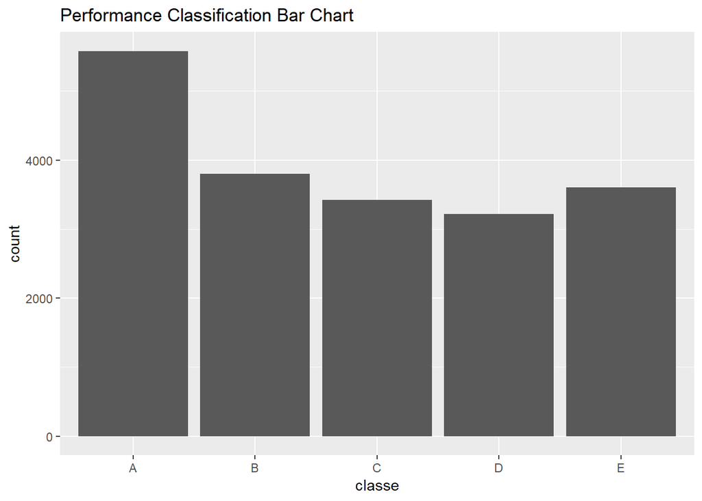

#### Classification Frequency Percentages (Training Data)

```
## classe
##         A         B         C         D         E
## 0.2843747 0.1935073 0.1743961 0.1638977 0.1838243
```

## Pre-Processing Data

### Removing Zero Covariates

#### Displaying first 10 non zero variables

```
##                       freqRatio percentUnique zeroVar  nzv
## new_window             47.33005    0.01019264   FALSE TRUE
## kurtosis_roll_belt   1921.60000    2.02323922   FALSE TRUE
## kurtosis_picth_belt   600.50000    1.61553358   FALSE TRUE
## kurtosis_yaw_belt      47.33005    0.01019264   FALSE TRUE
## skewness_roll_belt   2135.11111    2.01304658   FALSE TRUE
## skewness_roll_belt.1  600.50000    1.72255631   FALSE TRUE
## skewness_yaw_belt      47.33005    0.01019264   FALSE TRUE
## max_yaw_belt          640.53333    0.34654979   FALSE TRUE
## min_yaw_belt          640.53333    0.34654979   FALSE TRUE
## amplitude_yaw_belt     50.04167    0.02038528   FALSE TRUE
```

#### Tidying Data Set

Removed variables where vast majority of values were NA’s and removed first 6 columns used primary as identifiers.

The remaining pre-processed data sets have the following dimensions:

```r
dim(train)
```

```
## [1] 19622    53
```

```r
dim(test)
```

```
## [1] 20 53
```

## Splitting Data

```r
inTrain <- createDataPartition(y=train$classe,
                               p=0.8, list=FALSE)
training <- train[inTrain,]
validation <- train[-inTrain,]
```

## Machine Learning Model Formulation

### Model 1: Random Forest Cross Validation Method

Fitting a Random Forest Model based on training data

```
##
## Call:
##  randomForest(x = x, y = y, mtry = param$mtry)
##                Type of random forest: classification
##                      Number of trees: 500
## No. of variables tried at each split: 27
##
##         OOB estimate of  error rate: 0.54%
## Confusion matrix:
##      A    B    C    D    E class.error
## A 4459    4    0    0    1 0.001120072
## B   14 3017    7    0    0 0.006912442
## C    0   13 2715   10    0 0.008400292
## D    0    1   21 2549    2 0.009327633
## E    0    1    5    5 2875 0.003811504
```

Evaluating random forest cv model performance based on validation dataset

```
## Confusion Matrix and Statistics
##
##           Reference
## Prediction    A    B    C    D    E
##          A 1113    2    1    0    0
##          B    7  752    0    0    0
##          C    0    5  675    4    0
##          D    0    0    7  634    2
##          E    0    0    2    2  717
##
## Overall Statistics
##
##                Accuracy : 0.9918
##                  95% CI : (0.9885, 0.9944)
##     No Information Rate : 0.2855
##     P-Value [Acc > NIR] : < 2.2e-16
##
##                   Kappa : 0.9897
##  Mcnemar's Test P-Value : NA
##
## Statistics by Class:
##
##                      Class: A Class: B Class: C Class: D Class: E
## Sensitivity            0.9938   0.9908   0.9854   0.9906   0.9972
## Specificity            0.9989   0.9978   0.9972   0.9973   0.9988
## Pos Pred Value         0.9973   0.9908   0.9868   0.9860   0.9945
## Neg Pred Value         0.9975   0.9978   0.9969   0.9982   0.9994
## Prevalence             0.2855   0.1935   0.1746   0.1631   0.1833
## Detection Rate         0.2837   0.1917   0.1721   0.1616   0.1828
## Detection Prevalence   0.2845   0.1935   0.1744   0.1639   0.1838
## Balanced Accuracy      0.9963   0.9943   0.9913   0.9939   0.9980
```

### Model 2: Gradient Boosting Method

Fitting a Gradient Boosting Model with trees based on training data

```
## A gradient boosted model with multinomial loss function.
## 150 iterations were performed.
## There were 52 predictors of which 43 had non-zero influence.
```

Evaluating Gradient Boosting model performance based on validation dataset

```
## Confusion Matrix and Statistics
##
##           Reference
## Prediction    A    B    C    D    E
##          A 1100    6    7    1    2
##          B   32  708   15    2    2
##          C    0   23  651    9    1
##          D    3    3   16  614    7
##          E    1    7    7    8  698
##
## Overall Statistics
##
##                Accuracy : 0.9613
##                  95% CI : (0.9547, 0.9671)
##     No Information Rate : 0.2896
##     P-Value [Acc > NIR] : < 2.2e-16
##
##                   Kappa : 0.951
##  Mcnemar's Test P-Value : 4.998e-05
##
## Statistics by Class:
##
##                      Class: A Class: B Class: C Class: D Class: E
## Sensitivity            0.9683   0.9478   0.9353   0.9685   0.9831
## Specificity            0.9943   0.9839   0.9898   0.9912   0.9928
## Pos Pred Value         0.9857   0.9328   0.9518   0.9549   0.9681
## Neg Pred Value         0.9872   0.9877   0.9861   0.9939   0.9963
## Prevalence             0.2896   0.1904   0.1774   0.1616   0.1810
## Detection Rate         0.2804   0.1805   0.1659   0.1565   0.1779
## Detection Prevalence   0.2845   0.1935   0.1744   0.1639   0.1838
## Balanced Accuracy      0.9813   0.9659   0.9626   0.9798   0.9880
```

## Conclusion

Random Forest Model yields creater accuracy compared with the Gradient Booting method (99%>96%)

### Selecting Random Forest Model to use for prediction submission using test dataset

```r
FinalPred<-predict(RFmodeltrain,newdata = test)
FinalPreddf<-data.frame(test_ID=test$problem_id,PredictClass=FinalPred)
FinalPreddf
```

```
##    test_ID PredictClass
## 1        1            B
## 2        2            A
## 3        3            B
## 4        4            A
## 5        5            A
## 6        6            E
## 7        7            D
## 8        8            B
## 9        9            A
## 10      10            A
## 11      11            B
## 12      12            C
## 13      13            B
## 14      14            A
## 15      15            E
## 16      16            E
## 17      17            A
## 18      18            B
## 19      19            B
## 20      20            B
```

# Appendix

### Additional Data Exploration

#### Most relevant 20 variables on the model

```r
importance <- varImp(RFmodeltrain, scale=FALSE)
print(importance)
```

```
## rf variable importance
##
##   only 20 most important variables shown (out of 52)
##
##                      Overall
## roll_belt             1606.6
## pitch_forearm          963.7
## yaw_belt               899.7
## pitch_belt             747.0
## magnet_dumbbell_z      746.7
## magnet_dumbbell_y      708.6
## roll_forearm           697.1
## accel_dumbbell_y       378.4
## accel_forearm_x        306.5
## magnet_dumbbell_x      303.3
## roll_dumbbell          282.4
## accel_belt_z           274.0
## magnet_belt_z          266.4
## accel_dumbbell_z       256.5
## magnet_forearm_z       249.2
## total_accel_dumbbell   246.8
## gyros_belt_z           214.1
## magnet_belt_y          202.0
## magnet_belt_x          196.4
## yaw_arm                196.1
```

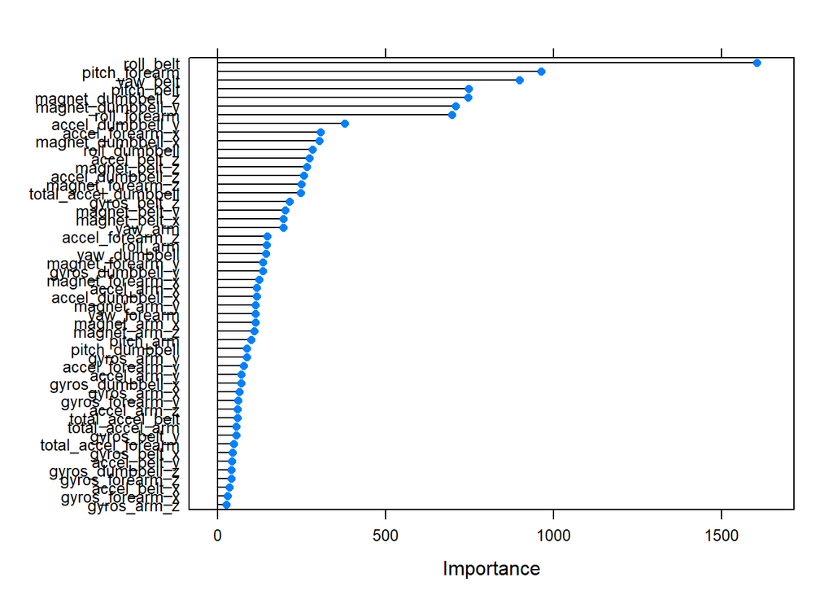

```r
plot(importance)
```

#### Feature Plot - Belt Euler Angles

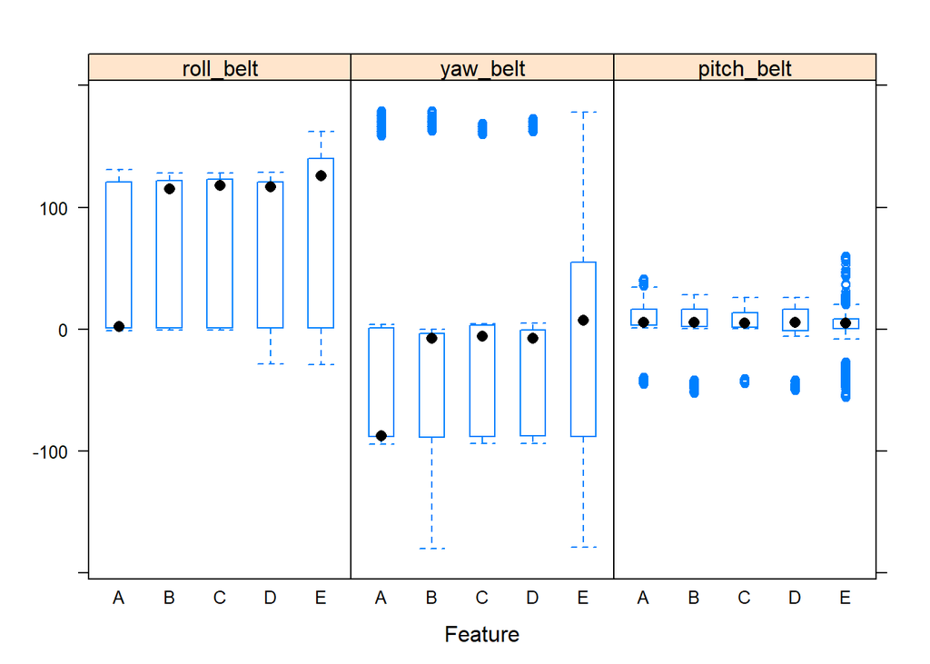

#### Belt Euler Angle Scatterplot by Classe

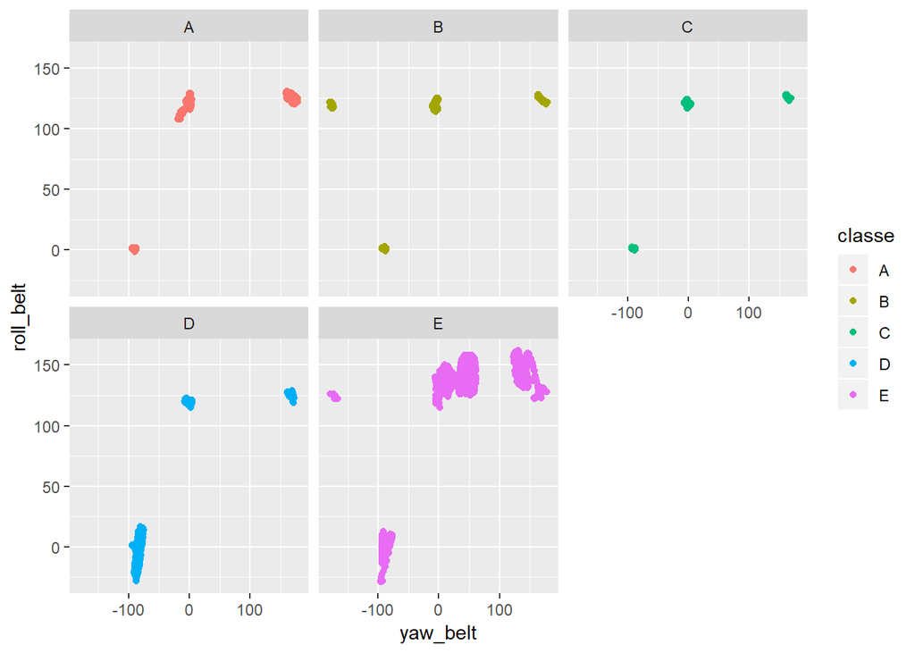

#### Feature BoxPlot - Dumbbell magnometer

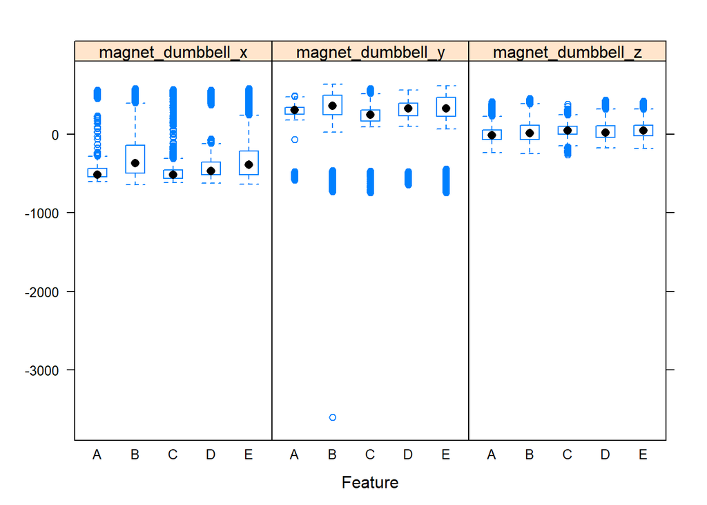

#### Dumbbell Magnometer Scatterplot by Classe

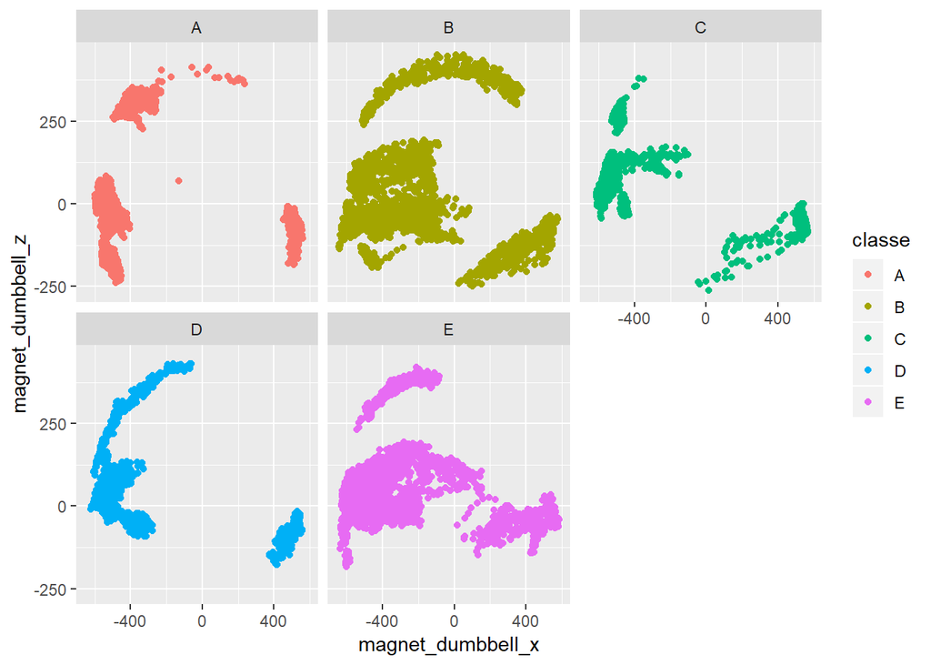